# Migration Department NDVI access

Simeon Lisovski

2018 M04 27

## Read first

This documentation explains how to access (noise reduced) NDVI data from our R:/ driv by loading it streight into your R environemnt.

3 Steps process:

1. Install required package and dependencies from GitHub:

```r
devtools::install_github("SLisovski/soiRSDA")
```

If you don’t have `devtools` installed already, install it first.

```r
install.packages("devtools")
```

You only have to do that once.

2. Create spatial polygon or coordinates for which you want to extract NDVI values.
3. Use function `getVHP` to extract values.

## The dataset

So far, the only available dataset is names `VHP.G16.C07.SM.csv` which is a combination of noise reduced NDVI and BT values from the NOAA AVHRR-VHP priduct. The spatial resolution is 16 km and the dataset starts in 1981 (till today). The AVHRR-VHP is a re-processed Vegetation Health data set derived from AVHRR GAC data. It was processed by the newly developed operational VHP system. For further unformation see: https://www.star.nesdis.noaa.gov/smcd/emb/vci/VH/vh_ftp.php

## Example

Here, I use the function to extract NDVI data for France from 2000.

```r
library(maptools)
  data("wrld_simpl")

Fra <- wrld_simpl[which(wrld_simpl@data[, 5]%in%"France"), ]
```

Next, I can use the function `getVHP` to extract the NDVI values:

```r
library(soiRSDA)

ndvi <- getVHP(Fra, dates = c("2000-01-01", "2000-12-31"), returnRast = TRUE)
```

```
##
Read 0.0% of 52 rows
Read 52 rows and 3091 (of 748009) columns from 5.762 GB file in 00:01:28
```

Several options exist;

1. `y` can be a point represented by a two-column matrix or data.frame, or `SpatialPoints`; `SpatialPolygons`.
2. if `y` is a single coordinate, you can specifiy a buffer around the coordinate (in meter) for which you want to extract NDVI values.
3. if path is set to `NULL` (default) the function will use the standart R drive path to locate the nessesary file. If you have downloaded the file onto another computer, you have to change the path manually.
4. The results can be provided either as a matrix with rows representing the temporal time series and columns presenting the extracted grid cells. The date can be derived via the row names of the matrix (seconds after `1970-01-01`). However, the results can also be provided as raster objects (default, `returnRast = TRUE`). If a raster will be returned for more than one week of data, the time will be presented in raster layers. The layer names contain all nessesary information on date.

NOTE: depending on how much data you extract (and how good your computer is), this process can take several minutes.

We can now extract the date vector and plot the ndvi values (here for two different time periods).

ASLO NOTE: values > 1 represents snow.

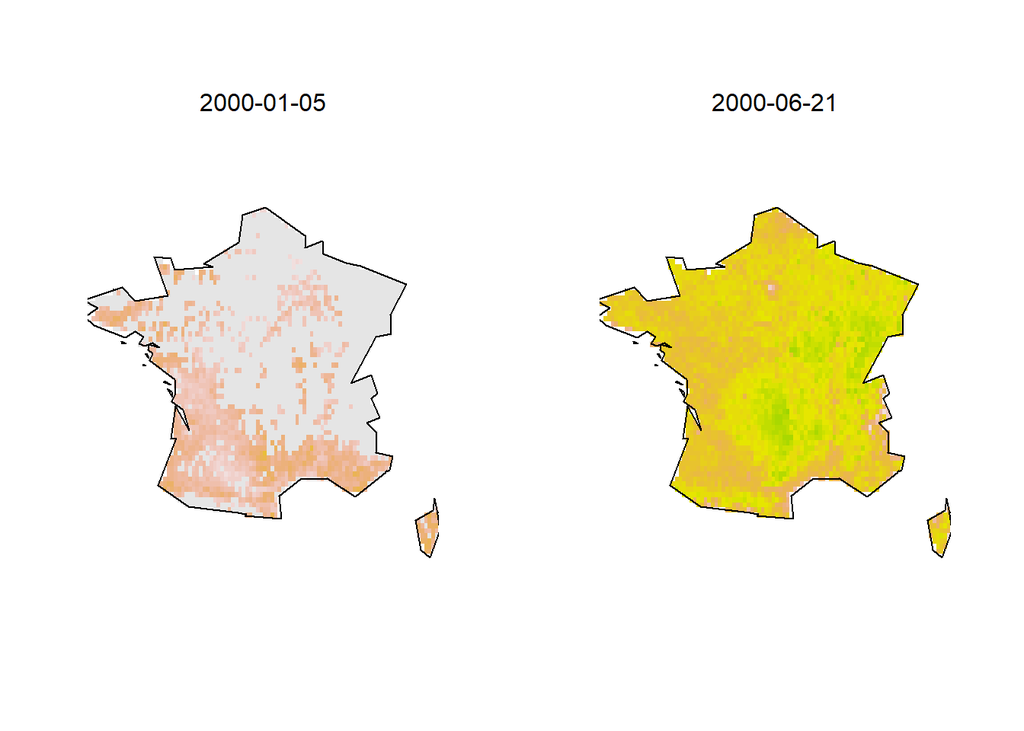

```r
date <- as.POSIXct(substring(names(ndvi), 3, 10), format = "%y.%m.%d", tz = "GMT")


opar <- par(mfrow = c(1,2), mar = c(3,3,4,1), bty = "n")
plot(ndvi[[1]], breaks = c(-2, seq(0, 1, length = 50), 2), col = c("transparent", rev(terrain.colors(49)), "grey90"),
     legend = FALSE, xaxt = "n", yaxt = "n")
plot(Fra, add = T)
mtext(date[1], 3)

plot(ndvi[[25]], breaks = c(-2, seq(0, 1, length = 50), 2), col = c("transparent", rev(terrain.colors(49)), "grey90"),
     legend = FALSE, xaxt = "n", yaxt = "n")
plot(Fra, add = T)
mtext(date[25], 3)
```

```r
par(opar)
```

We can also show the temporal dynamics of France in that year.

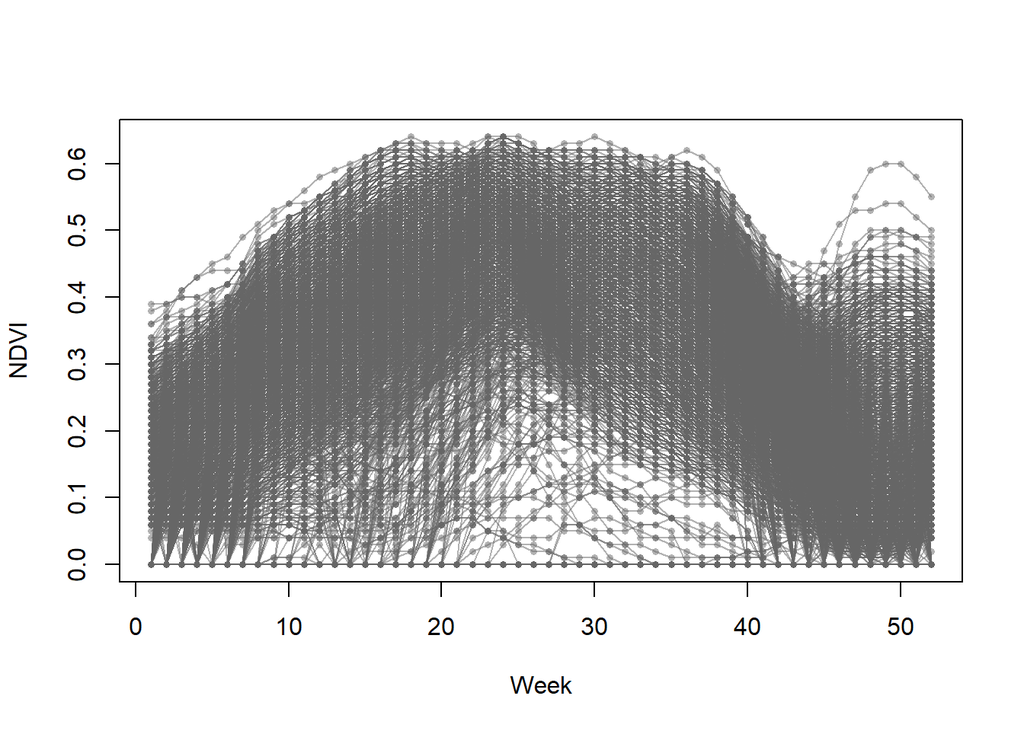

```r
ts <- as.matrix(ndvi)
  ts[ts>1 | ts<0] <- 0

matplot(t(ts), lty = 1, lwd = 1.2, col = adjustcolor("grey40", alpha.f = 0.5), type = "o", cex = 0.6, pch = 16, xlab = "Week", ylab = "NDVI")
```